# Airbnb Berlin Dataset

Airbnb data of Germany's capital Berlin. The dataset has over 22,552 listings and was scraped in November 2018.

The question for my model is: Can we estimate a daily price for a new accommodation that fits into its specific market environment and competitors in Berlin?

# 1. First View on the Data

```python
import numpy as np
import pandas as pd
import matplotlib.pyplot as plt
import seaborn as sns
import warnings
import plotly.offline as py
py.init_notebook_mode(connected=True)
import plotly.graph_objs as go
import plotly.tools as tls
warnings.filterwarnings('ignore')
%matplotlib inline
```

```python
df_raw = pd.read_csv('listings_summary.csv')
```

```python
df_raw.shape
```

```
(22552, 96)
```

```python
df_raw.info()
```

```
<class 'pandas.core.frame.DataFrame'>
RangeIndex: 22552 entries, 0 to 22551
Data columns (total 96 columns):
id                                  22552 non-null int64
listing_url                         22552 non-null object
scrape_id                           22552 non-null int64
last_scraped                        22552 non-null object
name                                22493 non-null object
summary                             21589 non-null object
space                               14020 non-null object
description                         22349 non-null object
experiences_offered                 22552 non-null object
neighborhood_overview               11540 non-null object
notes                               7215 non-null object
transit                             13036 non-null object
access                              10837 non-null object
interaction                         10406 non-null object
house_rules                         11449 non-null object
thumbnail_url                       0 non-null float64
medium_url                          0 non-null float64
picture_url                         22552 non-null object
xl_picture_url                      0 non-null float64
host_id                             22552 non-null int64
host_url                            22552 non-null object
host_name                           22526 non-null object
host_since                          22526 non-null object
host_location                       22436 non-null object
host_about                          11189 non-null object
host_response_time                  9658 non-null object
host_response_rate                  9657 non-null object
host_acceptance_rate                0 non-null float64
host_is_superhost                   22526 non-null object
host_thumbnail_url                  22526 non-null object
host_picture_url                    22526 non-null object
host_neighbourhood                  17458 non-null object
host_listings_count                 22526 non-null float64
host_total_listings_count           22526 non-null float64
host_verifications                  22552 non-null object
host_has_profile_pic                22526 non-null object
host_identity_verified              22526 non-null object
```

[output cut: 46 more lines]

```
review_scores_communication         18134 non-null float64
review_scores_location              18121 non-null float64
review_scores_value                 18117 non-null float64
requires_license                    22552 non-null object
license                             1638 non-null object
jurisdiction_names                  0 non-null float64
instant_bookable                    22552 non-null object
is_business_travel_ready            22552 non-null object
cancellation_policy                 22552 non-null object
require_guest_profile_picture       22552 non-null object
require_guest_phone_verification    22552 non-null object
calculated_host_listings_count      22552 non-null int64
reviews_per_month                   18638 non-null float64
dtypes: float64(21), int64(13), object(62)
memory usage: 16.5+ MB
```

Let's have a look of there are any duplicates:

```python
#Removal of possible duplicates:

df_raw.duplicated().sum()
df_raw.drop_duplicates(inplace=True)
```

```python
df_raw.columns
```

```
Index(['id', 'listing_url', 'scrape_id', 'last_scraped', 'name', 'summary',
       'space', 'description', 'experiences_offered', 'neighborhood_overview',
       'notes', 'transit', 'access', 'interaction', 'house_rules',
       'thumbnail_url', 'medium_url', 'picture_url', 'xl_picture_url',
       'host_id', 'host_url', 'host_name', 'host_since', 'host_location',
       'host_about', 'host_response_time', 'host_response_rate',
       'host_acceptance_rate', 'host_is_superhost', 'host_thumbnail_url',
       'host_picture_url', 'host_neighbourhood', 'host_listings_count',
       'host_total_listings_count', 'host_verifications',
       'host_has_profile_pic', 'host_identity_verified', 'street',
       'neighbourhood', 'neighbourhood_cleansed',
       'neighbourhood_group_cleansed', 'city', 'state', 'zipcode', 'market',
       'smart_location', 'country_code', 'country', 'latitude', 'longitude',
       'is_location_exact', 'property_type', 'room_type', 'accommodates',
       'bathrooms', 'bedrooms', 'beds', 'bed_type', 'amenities', 'square_feet',
       'price', 'weekly_price', 'monthly_price', 'security_deposit',
       'cleaning_fee', 'guests_included', 'extra_people', 'minimum_nights',
       'maximum_nights', 'calendar_updated', 'has_availability',
       'availability_30', 'availability_60', 'availability_90',
       'availability_365', 'calendar_last_scraped', 'number_of_reviews',
       'first_review', 'last_review', 'review_scores_rating',
       'review_scores_accuracy', 'review_scores_cleanliness',
       'review_scores_checkin', 'review_scores_communication',
       'review_scores_location', 'review_scores_value', 'requires_license',
       'license', 'jurisdiction_names', 'instant_bookable',
       'is_business_travel_ready', 'cancellation_policy',
       'require_guest_profile_picture', 'require_guest_phone_verification',
       'calculated_host_listings_count', 'reviews_per_month'],
      dtype='object')
```

# 2. Preprocessing the data

### 2.1 Deciding which features to work with

```python
pd.set_option('display.max_columns', None)
df_raw.head(20)
```

|  | id | listing_url | scrape_id | last_scraped | name | summary | space | description | experiences_offered | neighborhood_overview | notes | transit | access | interaction | house_rules | thumbnail_url | medium_url | picture_url | xl_picture_url | host_id | host_url | host_name | host_since | host_location | host_about | host_response_time | host_response_rate | host_acceptance_rate | host_is_superhost | … |
| --- | --- | --- | --- | --- | --- | --- | --- | --- | --- | --- | --- | --- | --- | --- | --- | --- | --- | --- | --- | --- | --- | --- | --- | --- | --- | --- | --- | --- | --- | --- |
| 0 | 2015 | https://www.airbnb.com/rooms/2015 | 20181107122246 | 2018-11-07 | Berlin-Mitte Value! Quiet courtyard/very central | Great location! 30 of 75 sq meters. This wood... | A+++ location! This „Einliegerwohnung“ is an e... | Great location! 30 of 75 sq meters. This wood... | none | It is located in the former East Berlin area o... | This is my home, not a hotel. I rent out occas... | Close to U-Bahn U8 and U2 (metro), Trams M12, ... | Simple kitchen/cooking, refrigerator, microwav... | Always available | No parties No events No pets No smoking, not e... | NaN | NaN | https://a0.muscache.com/im/pictures/260fd609-7... | NaN | 2217 | https://www.airbnb.com/users/show/2217 | Ian | 2008-08-18 | Key Biscayne, Florida, United States | Believe in sharing economy. | within an hour | 96% | NaN | t | … |
| 1 | 2695 | https://www.airbnb.com/rooms/2695 | 20181107122246 | 2018-11-07 | Prenzlauer Berg close to Mauerpark | NaN | In the summertime we are spending most of our ... | In the summertime we are spending most of our ... | none | NaN | NaN | Within walking distance you'll find the S-Bahn... | Außer deinem Zimmer kannst du noch die Küche u... | NaN | NaN | NaN | NaN | https://a0.muscache.com/im/pictures/97d4f6e8-1... | NaN | 2986 | https://www.airbnb.com/users/show/2986 | Michael | 2008-09-16 | Berlin, Berlin, Germany | Living with my wife in Berlin. Like travellin... | NaN | NaN | NaN | f | … |
| 2 | 3176 | https://www.airbnb.com/rooms/3176 | 20181107122246 | 2018-11-07 | Fabulous Flat in great Location | This beautiful first floor apartment is situa... | 1st floor (68m2) apartment on Kollwitzplatz/ P... | This beautiful first floor apartment is situa... | none | The neighbourhood is famous for its variety of... | We welcome FAMILIES and cater especially for y... | We are 5 min walk away from the tram M2, whic... | The apartment will be entirely yours. We are c... | Feel free to ask any questions prior to bookin... | It’s a non smoking flat, which likes to be tre... | NaN | NaN | https://a0.muscache.com/im/pictures/243355/84a... | NaN | 3718 | https://www.airbnb.com/users/show/3718 | Britta | 2008-10-19 | Coledale, New South Wales, Australia | We love to travel ourselves a lot and prefer t... | within a day | 100% | NaN | f | … |
| 3 | 3309 | https://www.airbnb.com/rooms/3309 | 20181107122246 | 2018-11-07 | BerlinSpot Schöneberg near KaDeWe | First of all: I prefer short-notice bookings. ... | Your room is really big and has 26 sqm, is ver... | First of all: I prefer short-notice bookings. ... | none | My flat is in the middle of West-Berlin, direc... | The flat is a strictly non-smoking facility! A... | The public transportation is excellent: Severa... | I do have a strictly non-smoker-flat. Keep th... | I'm working as a freelancing photographer. My ... | House-Rules and Information ..............(deu... | NaN | NaN | https://a0.muscache.com/im/pictures/29054294/b... | NaN | 4108 | https://www.airbnb.com/users/show/4108 | Jana | 2008-11-07 | Berlin, Berlin, Germany | ENJOY EVERY DAY AS IF IT'S YOUR LAST!!! \r\n\r... | NaN | NaN | NaN | f | … |
| 4 | 7071 | https://www.airbnb.com/rooms/7071 | 20181107122246 | 2018-11-07 | BrightRoom with sunny greenview! | Cozy and large room in the beautiful district ... | The BrightRoom is an approx. 20 sqm (215ft²), ... | Cozy and large room in the beautiful district ... | none | Great neighborhood with plenty of Cafés, Baker... | I hope you enjoy your stay to the fullest! Ple... | Best access to other parts of the city via pub... | The guests have access to the bathroom, a smal... | I am glad if I can give you advice or help as ... | Please take good care of everything during you... | NaN | NaN | https://a0.muscache.com/im/pictures/21278/32a1... | NaN | 17391 | https://www.airbnb.com/users/show/17391 | Bright | 2009-05-16 | Berlin, Berlin, Germany | I'm a creative person, adventurer, and travele... | within an hour | 100% | NaN | t | … |
| 5 | 9991 | https://www.airbnb.com/rooms/9991 | 20181107122246 | 2018-11-07 | Geourgeous flat - outstanding views | 4 bedroom with very large windows and outstand... | THE APPARTMENT - 4 bedroom (US, Germany: 5 roo... | 4 bedroom with very large windows and outstand... | none | Prenzlauer Berg is an amazing neighbourhood wh... | NaN | Excellent location regarding public transport ... | All amenities shared - nothing off limits | Guests will have the whole apartment to themse... | NaN | NaN | NaN | https://a0.muscache.com/im/pictures/42799131/5... | NaN | 33852 | https://www.airbnb.com/users/show/33852 | Philipp | 2009-08-25 | Berlin, Berlin, Germany | Born in Munich - lives in and loves Berlin. Wo... | within a few hours | 100% | NaN | f | … |
| 6 | 14325 | https://www.airbnb.com/rooms/14325 | 20181107122246 | 2018-11-07 | Apartment in Prenzlauer Berg | The apartment is located on the upper second f... | The apartment is located on the south-facing s... | The apartment is located on the upper second f... | none | NaN | NaN | NaN | NaN | NaN | No smoking, loud music or hosting parties at t... | NaN | NaN | https://a0.muscache.com/im/pictures/508703/249... | NaN | 55531 | https://www.airbnb.com/users/show/55531 | Chris + Oliver | 2009-11-18 | Berlin, Berlin, Germany | From Berlin, Germany. Working at ‘Welcome Beyo... | within a day | 100% | NaN | f | … |
| 7 | 16401 | https://www.airbnb.com/rooms/16401 | 20181107122246 | 2018-11-07 | APARTMENT TO RENT | NaN | Hello future guests! We want to rent our cute ... | Hello future guests! We want to rent our cute ... | none | NaN | NaN | NaN | NaN | NaN | NaN | NaN | NaN | https://a0.muscache.com/im/pictures/4753854/99... | NaN | 59666 | https://www.airbnb.com/users/show/59666 | Melanie | 2009-12-03 | Berlin, Berlin, Germany | I'm uncomplicated, funny, curious and I love t... | NaN | NaN | NaN | f | … |
| 8 | 16644 | https://www.airbnb.com/rooms/16644 | 20181107122246 | 2018-11-07 | In the Heart of Berlin - Kreuzberg | Light and sunny 2-Room-turn of the century-fla... | Rent in the heart of Berlin - Kreuzberg Newly ... | Light and sunny 2-Room-turn of the century-fla... | none | Our Part of Kreuzberg is just the best. Good v... | NaN | Ostbahnhof is close so you can get here by tra... | The guests use the whole apartment alone. Part... | The guest determines how much interaction they... | 1. No noise after 10 pm PLEASE. 2. Please do n... | NaN | NaN | https://a0.muscache.com/im/pictures/73759174/e... | NaN | 64696 | https://www.airbnb.com/users/show/64696 | Rene | 2009-12-20 | Santa Cruz, California, United States | Friendly and social. Likes to travel and enjoy... | within a few hours | 100% | NaN | f | … |
| 9 | 17409 | https://www.airbnb.com/rooms/17409 | 20181107122246 | 2018-11-07 | Downtown Above The Roofs In Berlin | The 25 sqm room is located in the heart of Ber... | A 25 sqm room in the heart of Berlin. Many pla... | The 25 sqm room is located in the heart of Ber... | none | You are in the heart of the former East-Berlin... | NaN | The subway is just a two minutes walk away, th... | The roof terrace and the kitchen can be used b... | I have seen some parts of the world and not on... | No smoking in the room, but possible outside o... | NaN | NaN | https://a0.muscache.com/im/pictures/9964850/c5... | NaN | 67590 | https://www.airbnb.com/users/show/67590 | Wolfram | 2010-01-04 | Berlin, Berlin, Germany | A Political journalist and well acquainted wit... | within an hour | 100% | NaN | t | … |
| 10 | 17904 | https://www.airbnb.com/rooms/17904 | 20181107122246 | 2018-11-07 | Beautiful Kreuzberg studio/WiFi (reg. pend.) | NaN | - beautiful studio apt in downtown Berlin - br... | - beautiful studio apt in downtown Berlin - br... | none | Die Wohnung liegt in Kreuzberg, das für seine ... | NaN | Die Wohnung liegt mitten in Berlin und hat ein... | - Wohnung ist voll eingerichtet, ihr braucht n... | Die Schlüssel sind bei Friedrich Vieth, dem Ha... | You would be expected to leave the apartment i... | NaN | NaN | https://a0.muscache.com/im/pictures/d9a6f8be-5... | NaN | 68997 | https://www.airbnb.com/users/show/68997 | Matthias | 2010-01-08 | Rio de Janeiro, Rio de Janeiro, Brazil | I used to work as a journalist all around the ... | NaN | NaN | NaN | f | … |
| 11 | 20858 | https://www.airbnb.com/rooms/20858 | 20181107122246 | 2018-11-07 | Designer Loft in Berlin Mitte | Bright and sunny condo with two balconies in a... | A 100 qm fancy and bright designer loft condo,... | Bright and sunny condo with two balconies in a... | none | Fantastic vibe in the middle of the popular Ka... | Please note: "The City Tax amounts to five per... | Public transportation like the Tram M1 is just... | The whole condo plus two balconies are yours. | Please contact my property manager Mr. Joerg P... | Arrival has to be completed until 9:00 pm late... | NaN | NaN | https://a0.muscache.com/im/pictures/108232/205... | NaN | 71331 | https://www.airbnb.com/users/show/71331 | Marc | 2010-01-18 | Hamburg, Hamburg, Germany | I am looking forward to your arrival, so I can... | within an hour | 100% | NaN | f | … |
| 12 | 21869 | https://www.airbnb.com/rooms/21869 | 20181107122246 | 2018-11-07 | Studio in the Heart of Kreuzberg | Light and sunny 1-Room-turn of the century-fla... | The apartment has two very comfortable high en... | Light and sunny 1-Room-turn of the century-fla... | none | Our Part of Kreuzberg is just the best. Good v... | NaN | Ostbahnhof is close so you can get here by tra... | The guests use the whole apartment alone. | The guest determines how much interaction they... | 1. No noise after 10 pm PLEASE. 2. Please do n... | NaN | NaN | https://a0.muscache.com/im/pictures/435605/4e8... | NaN | 64696 | https://www.airbnb.com/users/show/64696 | Rene | 2009-12-20 | Santa Cruz, California, United States | Friendly and social. Likes to travel and enjoy... | within a few hours | 100% | NaN | f | … |
| 13 | 22415 | https://www.airbnb.com/rooms/22415 | 20181107122246 | 2018-11-07 | Stylishly furnished 3 room flat | Artsy, light, spacious and cozy appartment in ... | Very nice furnished 2 bedroom apartment for su... | Very nice furnished 2 bedroom apartment for su... | none | NaN | please be aware theat when you check in later ... | NaN | all of the flat is yours only during your stay | Always available for questions on (Hidden by A... | No loud music ect. after 10 pm | NaN | NaN | https://a0.muscache.com/im/pictures/2797fe8d-6... | NaN | 86068 | https://www.airbnb.com/users/show/86068 | Kiki | 2010-02-27 | Berlin, Berlin, Germany | i am kiki 32 from berlin, germany. adventureou... | within a few hours | 75% | NaN | t | … |
| 14 | 22677 | https://www.airbnb.com/rooms/22677 | 20181107122246 | 2018-11-07 | Prenzel garden with leafy terrace | Comfortable, cozy and quiet 70m2 apartment plu... | Relax in the leafy 40m2 garden terrace and enj... | Comfortable, cozy and quiet 70m2 apartment plu... | none | I like especially the diversity of the area. Y... | CITY TAX: as of january 2014 every tourist ha... | You can reach a lot of interesting places by f... | You will have the apartment for yourself. The ... | We live near the apartment. You can always rea... | IMPORTANT INFORMATION and HOUSE RULES: CHECK I... | NaN | NaN | https://a0.muscache.com/im/pictures/10867210/7... | NaN | 87357 | https://www.airbnb.com/users/show/87357 | Ramfis | 2010-03-02 | Berlin, Berlin, Germany | I am an architect from Venezuela, I am married... | within an hour | 100% | NaN | t | … |
| 15 | 23834 | https://www.airbnb.com/rooms/23834 | 20181107122246 | 2018-11-07 | Apartment in the heart of Berlin | Beautiful and calm apartment in close vicinity... | News: Minimum stay: 60 nights The apartment ha... | Beautiful and calm apartment in close vicinity... | none | Description: A stone's throw away you'll find ... | NaN | The next metro station is Yorckstrasse. Next l... | Guests have access to all rooms as it is an en... | In case of any problem or questions guests can... | It is not allowed to smoke in the apartment. W... | NaN | NaN | https://a0.muscache.com/im/pictures/425641/8f8... | NaN | 94918 | https://www.airbnb.com/users/show/94918 | Tanja | 2010-03-17 | Berlin, Berlin, Germany | Hi,\r\nI was born and raised in Berlin in this... | within a day | 80% | NaN | f | … |
| 16 | 24569 | https://www.airbnb.com/rooms/24569 | 20181107122246 | 2018-11-07 | Sunny & Wheelchair accessible | NaN | The apartment has 150 sqm and is on the 4th fl... | The apartment has 150 sqm and is on the 4th fl... | none | NaN | NaN | NaN | NaN | NaN | NaN | NaN | NaN | https://a0.muscache.com/im/pictures/2019183/03... | NaN | 99662 | https://www.airbnb.com/users/show/99662 | Dominik | 2010-03-27 | Berlin, Berlin, Germany | Ich freue mich sehr darauf, Dich bald als mein... | within a day | 100% | NaN | f | … |
| 17 | 25653 | https://www.airbnb.com/rooms/25653 | 20181107122246 | 2018-11-07 | Sunny & stylish 150 sqm apartment | NaN | The apartment has 150 sqm and is on the 4th fl... | The apartment has 150 sqm and is on the 4th fl... | none | NaN | NaN | NaN | NaN | NaN | NaN | NaN | NaN | https://a0.muscache.com/im/pictures/144962/a45... | NaN | 99662 | https://www.airbnb.com/users/show/99662 | Dominik | 2010-03-27 | Berlin, Berlin, Germany | Ich freue mich sehr darauf, Dich bald als mein... | within a day | 100% | NaN | f | … |
| 18 | 26543 | https://www.airbnb.com/rooms/26543 | 20181107122246 | 2018-11-07 | Helmholtzplatz Bright&Spacious Apt. | This flat has permission to rent under Licence... | Newly renovated apartment with 2 bathrooms and... | This flat has permission to rent under Licence... | none | Vibes and full of lovely cafes and bistros and... | Should you be checking in quite late in the ev... | Public transport is fantastic in Berlin and Po... | Full free WIFI. Towels and Linen included in t... | Ms Elva is taking care of the apartment while ... | Strictly NO SMOKING within the apartment block... | NaN | NaN | https://a0.muscache.com/im/pictures/100083015/... | NaN | 112675 | https://www.airbnb.com/users/show/112675 | Terri | 2010-04-23 | Namibia | I live and work in Windhoek, Namibia. I am a p... | NaN | NaN | NaN | f | … |
| 19 | 28156 | https://www.airbnb.com/rooms/28156 | 20181107122246 | 2018-11-07 | Beautiful apartment in Prenzlauer Berg | The apartment is located on the upper ground f... | The apartment is located on the south-facing u... | The apartment is located on the upper ground f... | none | NaN | NaN | NaN | NaN | NaN | No smoking, loud music or hosting parties at t... | NaN | NaN | https://a0.muscache.com/im/pictures/508550/1f0... | NaN | 55531 | https://www.airbnb.com/users/show/55531 | Chris + Oliver | 2009-11-18 | Berlin, Berlin, Germany | From Berlin, Germany. Working at ‘Welcome Beyo... | within a day | 100% | NaN | f | … |

A lot of columns provide information that are not given if someone would advertise a new apartment. Such information could be: "host_url", "host_response_time" or "calendar_updated".

Other features share the same information, e.g: "country", "country_code" or "smart_location":

```python
df_raw['country'].head(1)
```

```
0    Germany
Name: country, dtype: object
```

```python
df_raw['smart_location'].head(1)
```

```
0    Berlin, Germany
Name: smart_location, dtype: object
```

Let's get rid of those features:

```python
save_col = ['id', 'name', 'summary', 'description', 'neighbourhood', 'neighbourhood_cleansed', 'neighbourhood_group_cleansed', 'zipcode',
           'latitude', 'longitude', 'property_type', 'room_type', 'accommodates', 'bathrooms', 'bedrooms', 'beds', 'bed_type', 'amenities', 'price',
           'security_deposit', 'cleaning_fee', 'guests_included', 'extra_people', 'minimum_nights', 'is_business_travel_ready', 'reviews_per_month', 'cancellation_policy']

df = df_raw[save_col].set_index('id')
```

```python
#Look on the new dataset

#pd.set_option('display.max_columns', None)
#df.head(20)
```

### 2.2 Deleting, filling NaNs & turning numerical strings to floats

```python
df.isnull().sum()
```

```
name                              59
summary                          963
description                      203
neighbourhood                   1131
neighbourhood_cleansed             0
neighbourhood_group_cleansed       0
zipcode                          656
latitude                           0
longitude                          0
property_type                      0
room_type                          0
accommodates                       0
bathrooms                         32
bedrooms                          18
beds                              40
bed_type                           0
amenities                          0
price                              0
security_deposit                9361
cleaning_fee                    7146
guests_included                    0
extra_people                       0
minimum_nights                     0
is_business_travel_ready           0
reviews_per_month               3914
cancellation_policy                0
dtype: int64
```

```python
df.dropna(subset=['name'], inplace=True)
```

```python
df.dtypes
```

```
name                             object
summary                          object
description                      object
neighbourhood                    object
neighbourhood_cleansed           object
neighbourhood_group_cleansed     object
zipcode                          object
latitude                        float64
longitude                       float64
property_type                    object
room_type                        object
accommodates                      int64
bathrooms                       float64
bedrooms                        float64
beds                            float64
bed_type                         object
amenities                        object
price                            object
security_deposit                 object
cleaning_fee                     object
guests_included                   int64
extra_people                     object
minimum_nights                    int64
is_business_travel_ready         object
reviews_per_month               float64
cancellation_policy              object
dtype: object
```

Some features, e.g the "price" column, provide numerical information but are objects. Let's convert these:

```python
#Turning strings to numerical values

df['price'] = df['price'].str.replace('$','').str.replace(',','').astype(float)
df['cleaning_fee'] = df['cleaning_fee'].str.replace('$','').str.replace(',','').astype(float)
df['security_deposit'] = df['security_deposit'].str.replace('$','').str.replace(',','').astype(float)
df['extra_people'] = df['extra_people'].str.replace('$','').str.replace(',','').astype(float)
```

```python
#Cleaning Zipcode -> Deleting NaNs & turning strings into numerical values
df.dropna(subset=['zipcode'], inplace=True)

df['zipcode']=df['zipcode'].astype(str).apply(lambda x: x.split()[0])

df.drop(df.index[df['zipcode']=='2455'], inplace = True)
df.drop(df.index[df['zipcode']=='3138'], inplace = True)
df.drop(df.index[df['zipcode']=='2439'], inplace = True)
df.drop(df.index[df['zipcode']=='6256'], inplace = True)
df.drop(df.index[df['zipcode']=='9248'], inplace = True)
df.drop(df.index[df['zipcode']=='5785'], inplace = True)
df.drop(df.index[df['zipcode']=='9244'], inplace = True)
df.drop(df.index[df['zipcode']=='z.'], inplace = True)

df['zipcode'] = df['zipcode'].astype(str).apply(lambda x: x.split(',')[0])

df['zipcode'] = df['zipcode'].astype('int64')
```

```python
df[df['bathrooms'].isnull()]['price'].min()
df[df['bathrooms'].isnull()]['price'].max()
df[df['bathrooms'].isnull()]['price'].mean()
df['bathrooms'].value_counts()
df[df['price'].between(19,150)]['bathrooms'].mean()

df['bathrooms']=df['bathrooms'].fillna(1)
```

```python
df['bedrooms']=df['bedrooms'].fillna(1)
```

```python
df[df['beds'].isnull()]['accommodates'].mean()
df['beds'] = df['beds'].fillna(2)
```

```python
df.drop(df.index[df['summary'].isnull()], inplace = True)
```

```python
#Dropping columns which we don't need
df.drop('reviews_per_month',axis=1,inplace=True)
df.drop('neighbourhood',axis=1,inplace=True)
```

```python
df.dtypes
```

```
name                             object
summary                          object
description                      object
neighbourhood_cleansed           object
neighbourhood_group_cleansed     object
zipcode                           int64
latitude                        float64
longitude                       float64
property_type                    object
room_type                        object
accommodates                      int64
bathrooms                       float64
bedrooms                        float64
beds                            float64
bed_type                         object
amenities                        object
price                           float64
security_deposit                float64
cleaning_fee                    float64
guests_included                   int64
extra_people                    float64
minimum_nights                    int64
is_business_travel_ready         object
cancellation_policy              object
dtype: object
```

```python
#Turning float values to integers if possible to optimize the performance
df['beds'].unique()
df['extra_people'].unique()
df['bedrooms'].unique()

df['beds'] = df['beds'].astype(int)
df['extra_people'] = df['extra_people'].astype(int)
df['bedrooms'] = df['bedrooms'].astype(int)
```

```python
df.isnull().sum()
```

```
name                               0
summary                            0
description                        0
neighbourhood_cleansed             0
neighbourhood_group_cleansed       0
zipcode                            0
latitude                           0
longitude                          0
property_type                      0
room_type                          0
accommodates                       0
bathrooms                          0
bedrooms                           0
beds                               0
bed_type                           0
amenities                          0
price                              0
security_deposit                8575
cleaning_fee                    6526
guests_included                    0
extra_people                       0
minimum_nights                     0
is_business_travel_ready           0
cancellation_policy                0
dtype: int64
```

```python
df.columns
```

```
Index(['name', 'summary', 'description', 'neighbourhood_cleansed',
       'neighbourhood_group_cleansed', 'zipcode', 'latitude', 'longitude',
       'property_type', 'room_type', 'accommodates', 'bathrooms', 'bedrooms',
       'beds', 'bed_type', 'amenities', 'price', 'security_deposit',
       'cleaning_fee', 'guests_included', 'extra_people', 'minimum_nights',
       'is_business_travel_ready', 'cancellation_policy'],
      dtype='object')
```

There are still a lot of entries missing in the "security_deposit" and the "cleaning_fee" columns. I'll fill those missing values with Linear Regression. But first, let's check the distribution of the price column:

```python
df['price'].describe()
```

```
count    20902.000000
mean        61.338867
std        129.494641
min          0.000000
25%         30.000000
50%         45.000000
75%         70.000000
max       9000.000000
Name: price, dtype: float64
```

...and delete all entries equal to 0....

```python
df.drop(df.index[df['price']==0], inplace=True)
```

Finally, let's exclude all "price" outliers from further analysis. 75% of the apartments charge up to 70€ - but the maximum value is 9000€. 79 entries will be excluded.

```python
df = df[((df.price - df.price.mean()) / df.price.std()).abs() < 3]
```

## Filling missing values by Linear Regression

An additional idea to improve the final model would be to instantiate another algorithm who predicts such outliers. But that's beyond the scope of this project.

```python
q_clean = df[df['security_deposit'].notnull()]
q_null = df[df['security_deposit'].isnull()]

q_clean = q_clean[((q_clean.security_deposit - q_clean.security_deposit.mean()) / q_clean.security_deposit.std()).abs() < 3]

df = pd.concat([q_clean,q_null], axis=0)
```

```python
c_clean = df[df['cleaning_fee'].notnull()]
c_null = df[df['cleaning_fee'].isnull()]

c_clean = c_clean[((c_clean.cleaning_fee - c_clean.cleaning_fee.mean()) / c_clean.cleaning_fee.std()).abs() < 3]

df = pd.concat([q_clean,q_null], axis=0)
```

```python
df.info()
```

```
<class 'pandas.core.frame.DataFrame'>
Int64Index: 20592 entries, 2015 to 29867352
Data columns (total 24 columns):
name                            20592 non-null object
summary                         20592 non-null object
description                     20592 non-null object
neighbourhood_cleansed          20592 non-null object
neighbourhood_group_cleansed    20592 non-null object
zipcode                         20592 non-null int64
latitude                        20592 non-null float64
longitude                       20592 non-null float64
property_type                   20592 non-null object
room_type                       20592 non-null object
accommodates                    20592 non-null int64
bathrooms                       20592 non-null float64
bedrooms                        20592 non-null int64
beds                            20592 non-null int64
bed_type                        20592 non-null object
amenities                       20592 non-null object
price                           20592 non-null float64
security_deposit                12045 non-null float64
cleaning_fee                    14106 non-null float64
guests_included                 20592 non-null int64
extra_people                    20592 non-null int64
minimum_nights                  20592 non-null int64
is_business_travel_ready        20592 non-null object
cancellation_policy             20592 non-null object
dtypes: float64(6), int64(7), object(11)
memory usage: 3.9+ MB
```

```python
#Filling null values in the column 'cleaning_fee' by Linear Regression. Therefore setting up a sub_df to work with:

sub_df = df[['accommodates', 'bathrooms', 'bedrooms',
       'beds',  'price', 'cleaning_fee']]
```

```python
train_data = sub_df[sub_df['cleaning_fee'].notnull()]

test_data  = sub_df[sub_df['cleaning_fee'].isnull()]


# define X
X_train = train_data.drop('cleaning_fee', axis=1)
X_test  = test_data.drop('cleaning_fee', axis=1)

# define y
y_train = train_data['cleaning_fee']
```

```python
# import Linear Regression
from sklearn.linear_model import LinearRegression

# instantiate
linreg = LinearRegression()

# fit model to training data
linreg.fit(X_train, y_train)
```

```
LinearRegression(copy_X=True, fit_intercept=True, n_jobs=1, normalize=False)
```

```python
#Predictions
y_test = linreg.predict(X_test)
```

```python
y_test = pd.DataFrame(y_test)
y_test.columns = ['cleaning_fee']
print(y_test.shape)
y_test.head()
```

```
(6486, 1)
```

|  | cleaning_fee |
| --- | --- |
| 0 | 27.368001 |
| 1 | 29.333144 |
| 2 | 52.587304 |
| 3 | 18.656644 |
| 4 | 21.230454 |

```python
prelim_index = pd.DataFrame(X_test.index)
prelim_index.columns = ['prelim']

# ... and concat this dataframe with y_test
y_test = pd.concat([y_test, prelim_index], axis=1)
y_test.set_index(['prelim'], inplace=True)
y_test.head()
```

| prelim | cleaning_fee |
| --- | --- |
| 38074 | 27.368001 |
| 68448 | 29.333144 |
| 159454 | 52.587304 |
| 358746 | 18.656644 |
| 387607 | 21.230454 |

```python
new_test_data = pd.concat([X_test, y_test], axis=1)
```

```python
sub_df_new = pd.concat([new_test_data, train_data], axis=0)

print(sub_df_new.shape)
sub_df_new.head()
```

```
(20592, 6)
```

|  | accommodates | bathrooms | bedrooms | beds | price | cleaning_fee |
| --- | --- | --- | --- | --- | --- | --- |
| 38074 | 2 | 1.0 | 1 | 1 | 80.0 | 27.368001 |
| 68448 | 4 | 1.0 | 0 | 2 | 84.0 | 29.333144 |
| 159454 | 6 | 1.0 | 2 | 4 | 161.0 | 52.587304 |
| 358746 | 2 | 1.0 | 1 | 1 | 36.0 | 18.656644 |
| 387607 | 2 | 1.0 | 1 | 1 | 49.0 | 21.230454 |

```python
df.drop(['accommodates', 'bathrooms', 'bedrooms',
       'beds',  'price', 'cleaning_fee'],
            axis=1, inplace=True)

df = pd.concat([sub_df_new, df], axis=1)

print(df.shape)
df.head(2)
```

```
(20592, 24)
```

|  | accommodates | bathrooms | bedrooms | beds | price | cleaning_fee | name | summary | description | neighbourhood_cleansed | neighbourhood_group_cleansed | zipcode | latitude | longitude | property_type | room_type | bed_type | amenities | security_deposit | guests_included | extra_people | minimum_nights | is_business_travel_ready | cancellation_policy |
| --- | --- | --- | --- | --- | --- | --- | --- | --- | --- | --- | --- | --- | --- | --- | --- | --- | --- | --- | --- | --- | --- | --- | --- | --- |
| 2015 | 3 | 1.0 | 1 | 2 | 60.0 | 30.0 | Berlin-Mitte Value! Quiet courtyard/very central | Great location! 30 of 75 sq meters. This wood... | Great location! 30 of 75 sq meters. This wood... | Brunnenstr. Süd | Mitte | 10119 | 52.534537 | 13.402557 | Guesthouse | Entire home/apt | Real Bed | {TV,"Cable TV",Wifi,Kitchen,Gym,Heating,"Famil... | 200.0 | 1 | 28 | 4 | f | strict_14_with_grace_period |
| 3176 | 4 | 1.0 | 1 | 2 | 90.0 | 50.0 | Fabulous Flat in great Location | This beautiful first floor apartment is situa... | This beautiful first floor apartment is situa... | Prenzlauer Berg Südwest | Pankow | 10405 | 52.534996 | 13.417579 | Apartment | Entire home/apt | Real Bed | {Internet,Wifi,Kitchen,"Buzzer/wireless interc... | 200.0 | 2 | 20 | 62 | f | strict_14_with_grace_period |

```python
df.info()
```

```
<class 'pandas.core.frame.DataFrame'>
Int64Index: 20592 entries, 2015 to 29867352
Data columns (total 24 columns):
accommodates                    20592 non-null int64
bathrooms                       20592 non-null float64
bedrooms                        20592 non-null int64
beds                            20592 non-null int64
price                           20592 non-null float64
cleaning_fee                    20592 non-null float64
name                            20592 non-null object
summary                         20592 non-null object
description                     20592 non-null object
neighbourhood_cleansed          20592 non-null object
neighbourhood_group_cleansed    20592 non-null object
zipcode                         20592 non-null int64
latitude                        20592 non-null float64
longitude                       20592 non-null float64
property_type                   20592 non-null object
room_type                       20592 non-null object
bed_type                        20592 non-null object
amenities                       20592 non-null object
security_deposit                12045 non-null float64
guests_included                 20592 non-null int64
extra_people                    20592 non-null int64
minimum_nights                  20592 non-null int64
is_business_travel_ready        20592 non-null object
cancellation_policy             20592 non-null object
dtypes: float64(6), int64(7), object(11)
memory usage: 3.9+ MB
```

Filling null values in the column 'security_deposit' by Linear Regression. Similar to "cleaning_fee:

```python
sub_df = df[['accommodates', 'bathrooms', 'bedrooms',
               'beds',  'price', 'security_deposit']]

train_data = sub_df[sub_df['security_deposit'].notnull()]
test_data  = sub_df[sub_df['security_deposit'].isnull()]

# define X
X_train = train_data.drop('security_deposit', axis=1)
X_test  = test_data.drop('security_deposit', axis=1)

# define y
y_train = train_data['security_deposit']

from sklearn.linear_model import LinearRegression

# instantiate
linreg = LinearRegression()
# fit model to training data
linreg.fit(X_train, y_train)



y_test = linreg.predict(X_test)

y_test = pd.DataFrame(y_test)
y_test.columns = ['security_deposit']
print(y_test.shape)
y_test.head()


prelim_index = pd.DataFrame(X_test.index)
prelim_index.columns = ['prelim']

# ... and concat this dataframe with y_test
y_test = pd.concat([y_test, prelim_index], axis=1)
y_test.set_index(['prelim'], inplace=True)
y_test.head()



new_test_data = pd.concat([X_test, y_test], axis=1)


sub_df_new = pd.concat([new_test_data, train_data], axis=0)

print(sub_df_new.shape)
sub_df_new.head()



df.drop(['accommodates', 'bathrooms', 'bedrooms',
                   'beds',  'price', 'security_deposit'],
                        axis=1, inplace=True)

df = pd.concat([sub_df_new, df], axis=1)

print(df.shape)
df.head(2)
```

```
(8547, 1)
(20592, 6)
(20592, 24)
```

|  | accommodates | bathrooms | bedrooms | beds | price | security_deposit | cleaning_fee | name | summary | description | neighbourhood_cleansed | neighbourhood_group_cleansed | zipcode | latitude | longitude | property_type | room_type | bed_type | amenities | guests_included | extra_people | minimum_nights | is_business_travel_ready | cancellation_policy |
| --- | --- | --- | --- | --- | --- | --- | --- | --- | --- | --- | --- | --- | --- | --- | --- | --- | --- | --- | --- | --- | --- | --- | --- | --- |
| 2015 | 3 | 1.0 | 1 | 2 | 60.0 | 200.0 | 30.0 | Berlin-Mitte Value! Quiet courtyard/very central | Great location! 30 of 75 sq meters. This wood... | Great location! 30 of 75 sq meters. This wood... | Brunnenstr. Süd | Mitte | 10119 | 52.534537 | 13.402557 | Guesthouse | Entire home/apt | Real Bed | {TV,"Cable TV",Wifi,Kitchen,Gym,Heating,"Famil... | 1 | 28 | 4 | f | strict_14_with_grace_period |
| 3176 | 4 | 1.0 | 1 | 2 | 90.0 | 200.0 | 50.0 | Fabulous Flat in great Location | This beautiful first floor apartment is situa... | This beautiful first floor apartment is situa... | Prenzlauer Berg Südwest | Pankow | 10405 | 52.534996 | 13.417579 | Apartment | Entire home/apt | Real Bed | {Internet,Wifi,Kitchen,"Buzzer/wireless interc... | 2 | 20 | 62 | f | strict_14_with_grace_period |

# 3. Further Feature Engineering:

### Getting the distance from Berlin's centroid

```python
from geopy.distance import great_circle
```

```python
def distance(lat, lon):
    centre = (52.5027778, 13.404166666666667)
    accommodation = (lat, lon)
    return great_circle(centre, accommodation).km
```

```python
df['distance'] = df.apply(lambda x: distance(x.latitude, x.longitude), axis=1)
```

# 4. Exploratory Data Analysis

## 4.1. Distribution of the price based on neighbourhood

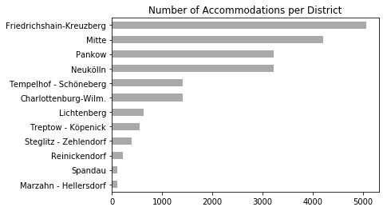

```python
df['neighbourhood_group_cleansed'].value_counts().sort_values().plot(kind='barh', color='darkgrey')
plt.title('Number of Accommodations per District');
```

```python
#let's find out more about our neiberhoods presented 'Mitte', 'Pankow', 'Tempelhof - Schöneberg', 'Friedrichshain-Kreuzberg', 'Charlottenburg-Wilm.', 'Neukölln','Treptow - Köpenick', 'Steglitz - Zehlendorf', 'Reinickendorf','Lichtenberg', 'Marzahn - Hellersdorf' and 'Spandau'

#Mitte
sub_1=df.loc[df['neighbourhood_group_cleansed'] == 'Mitte']
price_sub1=sub_1[['price']]
#Pankow
sub_2=df.loc[df['neighbourhood_group_cleansed'] == 'Pankow']
price_sub2=sub_2[['price']]
#Tempelhof - Schöneberg
sub_3=df.loc[df['neighbourhood_group_cleansed'] == 'Tempelhof - Schöneberg']
price_sub3=sub_3[['price']]
#Friedrichshain-Kreuzberg
sub_4=df.loc[df['neighbourhood_group_cleansed'] == 'Friedrichshain-Kreuzberg']
price_sub4=sub_4[['price']]
#Charlottenburg-Wilm.
sub_5=df.loc[df['neighbourhood_group_cleansed'] == 'Charlottenburg-Wilm.']
price_sub5=sub_5[['price']]
#Neukölln
sub_6=df.loc[df['neighbourhood_group_cleansed'] == 'Neukölln']
price_sub6=sub_6[['price']]
#Treptow - Köpenick
sub_7=df.loc[df['neighbourhood_group_cleansed'] == 'Treptow - Köpenick']
price_sub7=sub_7[['price']]
#Steglitz - Zehlendorf
sub_8=df.loc[df['neighbourhood_group_cleansed'] == 'Steglitz - Zehlendorf']
price_sub8=sub_8[['price']]
#Reinickendorf
sub_9=df.loc[df['neighbourhood_group_cleansed'] == 'Reinickendorf']
price_sub9=sub_9[['price']]
#Lichtenberg
sub_10=df.loc[df['neighbourhood_group_cleansed'] == 'Lichtenberg']
price_sub10=sub_10[['price']]
#Marzahn - Hellersdorf
sub_11=df.loc[df['neighbourhood_group_cleansed'] == 'Marzahn - Hellersdorf']
price_sub11=sub_11[['price']]
#Spandau
sub_12=df.loc[df['neighbourhood_group_cleansed'] == 'Spandau']
price_sub12=sub_12[['price']]



#putting all the prices' dfs in the list
price_list_by_n=[price_sub1, price_sub2, price_sub3, price_sub4, price_sub5, price_sub6, price_sub7, price_sub8, price_sub9, price_sub10, price_sub11, price_sub12]
```

```python
#creating an empty list that we will append later with price distributions for each neighbourhood_group
p_l_b_n_2=[]

#creating list with known values in neighbourhood_group column
nei_list=['Mitte', 'Pankow', 'Tempelhof - Schöneberg', 'Friedrichshain-Kreuzberg', 'Charlottenburg-Wilm.', 'Neukölln','Treptow - Köpenick', 'Steglitz - Zehlendorf', 'Reinickendorf','Lichtenberg', 'Marzahn - Hellersdorf','Spandau']

#creating a for loop to get statistics for price ranges and append it to our empty list
for x in price_list_by_n:
    i=x.describe(percentiles=[.25, .50, .75])
    i=i.iloc[3:]
    i.reset_index(inplace=True)
    i.rename(columns={'index':'Stats'}, inplace=True)
    p_l_b_n_2.append(i)
#changing names of the price column to the area name for easier reading of the table
p_l_b_n_2[0].rename(columns={'price':nei_list[0]}, inplace=True)
p_l_b_n_2[1].rename(columns={'price':nei_list[1]}, inplace=True)
p_l_b_n_2[2].rename(columns={'price':nei_list[2]}, inplace=True)
p_l_b_n_2[3].rename(columns={'price':nei_list[3]}, inplace=True)
p_l_b_n_2[4].rename(columns={'price':nei_list[4]}, inplace=True)
p_l_b_n_2[5].rename(columns={'price':nei_list[5]}, inplace=True)
p_l_b_n_2[6].rename(columns={'price':nei_list[6]}, inplace=True)
p_l_b_n_2[7].rename(columns={'price':nei_list[7]}, inplace=True)
p_l_b_n_2[8].rename(columns={'price':nei_list[8]}, inplace=True)
p_l_b_n_2[9].rename(columns={'price':nei_list[9]}, inplace=True)
p_l_b_n_2[10].rename(columns={'price':nei_list[10]}, inplace=True)
p_l_b_n_2[11].rename(columns={'price':nei_list[11]}, inplace=True)

#finilizing our dataframe for final view
stat_df=p_l_b_n_2
stat_df=[df.set_index('Stats') for df in stat_df]
stat_df=stat_df[0].join(stat_df[1:])
stat_df
```

| Stats | Mitte | Pankow | Tempelhof - Schöneberg | Friedrichshain-Kreuzberg | Charlottenburg-Wilm. | Neukölln | Treptow - Köpenick | Steglitz - Zehlendorf | Reinickendorf | Lichtenberg | Marzahn - Hellersdorf | Spandau |
| --- | --- | --- | --- | --- | --- | --- | --- | --- | --- | --- | --- | --- |
| min | 1.0 | 9.0 | 9.0 | 8.0 | 10.00 | 9.0 | 10.0 | 8.00 | 10.0 | 11.0 | 14.0 | 12.0 |
| 25% | 30.0 | 35.0 | 30.0 | 33.0 | 31.25 | 29.0 | 29.0 | 29.25 | 26.0 | 25.0 | 25.0 | 27.0 |
| 50% | 49.0 | 50.0 | 45.0 | 48.0 | 48.00 | 40.0 | 43.5 | 41.00 | 35.0 | 38.0 | 40.0 | 38.0 |
| 75% | 76.5 | 78.0 | 65.0 | 70.0 | 75.00 | 55.0 | 65.0 | 65.00 | 52.0 | 55.0 | 69.0 | 69.5 |
| max | 439.0 | 400.0 | 400.0 | 444.0 | 400.00 | 400.0 | 390.0 | 400.00 | 225.0 | 418.0 | 220.0 | 290.0 |

Most of the price seem to circle around the same area. Just Reinickendorf, Lichtenberg and Spandau are a lot cheaper compared to the average

```
Text(0.5,1,'Density and distribution of prices for each neighberhood_group')
```

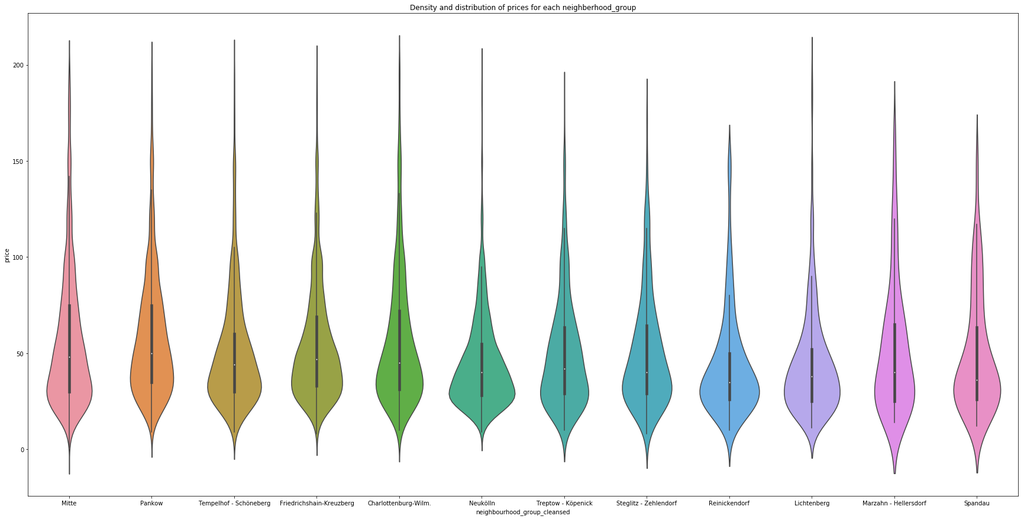

```python
#creating a sub-dataframe with no extreme values / less than 200
plt.figure(figsize=[30,15])

sub_13=df[df.price < 200]
#using violinplot to showcase density and distribtuion of prices
viz_2=sns.violinplot(data=sub_13, x='neighbourhood_group_cleansed', y='price')
viz_2.set_title('Density and distribution of prices for each neighberhood_group')
```

```
No handles with labels found to put in legend.
```

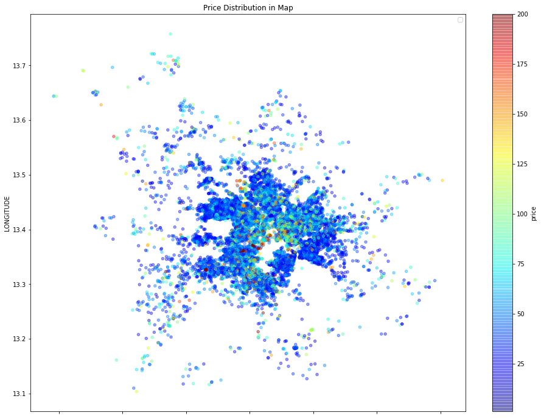

```python
lo_pri = df[df['price']<=200]

viz_4 = lo_pri.plot(kind='scatter', x='latitude', y='longitude', c='price',
                  cmap=plt.get_cmap('jet'), colorbar=True, alpha=0.4, figsize=(16,12),
                    fontsize=10, title='Price Distribution in Map')
plt.xlabel('LATITUDE')
plt.ylabel('LONGITUDE')

viz_4.legend()
```

```python
import folium
from folium.plugins import MarkerCluster
from folium import plugins
print('Berlin Price Map')
Long = 13.404954
Lat = 52.520008


def color_producer(crea):
    if crea < 45:
        return 'green'
    elif 45 <= crea< 70:
        return 'orange'
    else:
        return 'red'


mapdf1=folium.Map([Lat,Long],zoom_start=10,)

mapdf1_rooms_map=plugins.MarkerCluster().add_to(mapdf1)

for lat,lon,pri,room in zip(df.latitude,df.longitude, df.price, df.room_type):
    folium.Marker(location=[lat,lon],icon=folium.Icon(color=color_producer(pri)), popup=(str(room)+ ':\n'+ str(pri)+'$')).add_to(mapdf1_rooms_map)
mapdf1.add_child(mapdf1_rooms_map)

mapdf1.save('Berlin Price Map.html')
```

```
Berlin Price Map
```

## 4.2 Distribution of the Roomtypes

```
Text(0.5,1,'Mean Price Based on Roomtype')
```

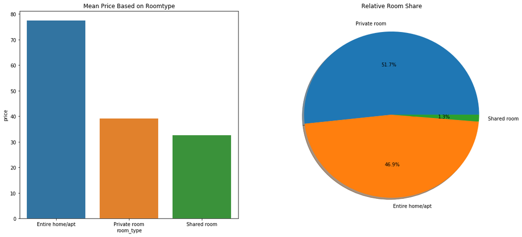

```python
df_room = pd.DataFrame(df.groupby(['room_type'])['price'].agg(np.mean))


f,ax=plt.subplots(1,2,figsize=(18,8))
df['room_type'].value_counts().plot(kind='pie', ax=ax[1], autopct='%1.1f%%', shadow=True,)
ax[1].set_title('Relative Room Share')
ax[1].set_ylabel('')


sns.barplot(x=df_room.index, y='price',ax=ax[0], data=df_room)
ax[0].set_title('Mean Price Based on Roomtype')
```

## 4.3 Amenity Availability

```
Text(0.5,1,'AMENITY COUNT')
```

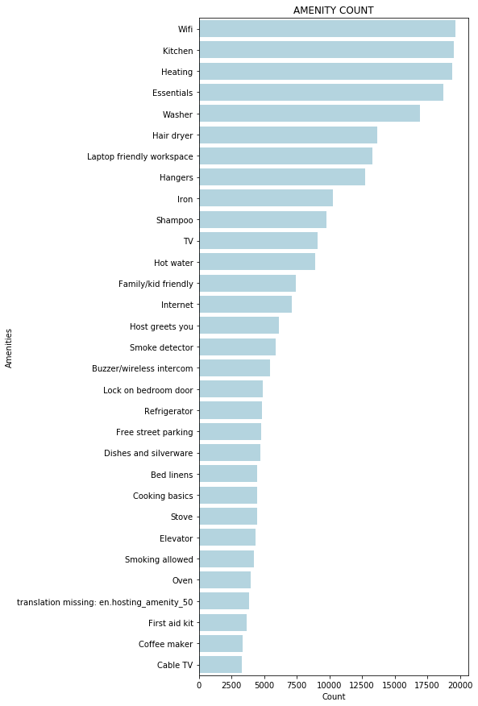

```python
from collections import Counter

amen = Counter()

df['amenities'].str.strip('{}').str.replace('"','').str.lstrip('/').str.rstrip('/').str.split(',').apply(amen.update)

df_amen = pd.DataFrame(data=amen.most_common(31), columns=['Amenities', 'Count'])



f, ax = plt.subplots(figsize=(6, 15))

sns.barplot(x='Count', y='Amenities', data=df_amen, color='lightblue').set_title('AMENITY COUNT')
```

Let's add columns with amenities that are somewhat unique and not offered by all hosts:

- a laptop-friendly workspace
- a First aid kit
- family friendly accommodation
- being greeted by the host.

After doing this, let's drop the original column:

```python
df['Laptop friendly'] = df['amenities'].str.contains('Laptop friendly workspace').astype(int)
df['Family friendly'] = df['amenities'].str.contains('Family/kid friendly').astype(int)
df['Host greets you'] = df['amenities'].str.contains('Host greets you').astype(int)
df['First aid kit'] = df['amenities'].str.contains('First aid kit').astype(int)

df.drop('amenities', axis=1, inplace=True)
```

## 4.4 Popular wordings in the name

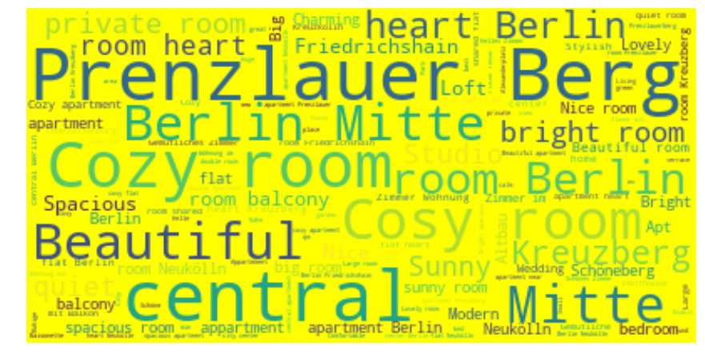

```python
from wordcloud import WordCloud, ImageColorGenerator
text = " ".join(str(each) for each in df.name)
# Create and generate a word cloud image:
wordcloud = WordCloud(max_words=200, background_color="yellow").generate(text)
plt.figure(figsize=(10,6))
plt.figure(figsize=(15,10))
# Display the generated image:
plt.imshow(wordcloud, interpolation='bilinear')
plt.axis("off")
plt.show()
```

## 4.5 Correlation map

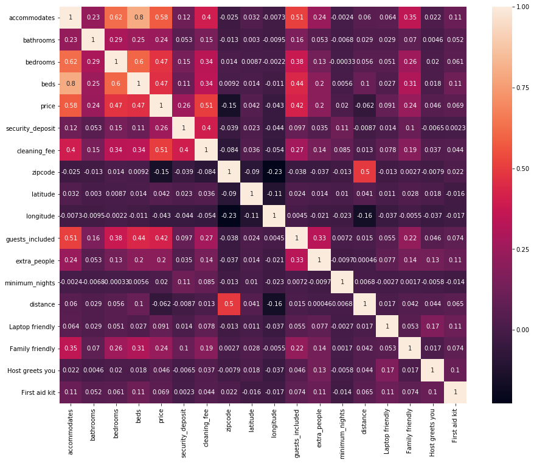

```python
plt.figure(figsize=[15,12])
sns.heatmap(df.corr('pearson'), annot=True, )
```

The price and the cleaning_fee features seem to have a moderate correlation. Let's have a closer look with a scatterplot:

```
Text(0.5,1,'\nRelation between Cleaning Fee & Price \n')
```

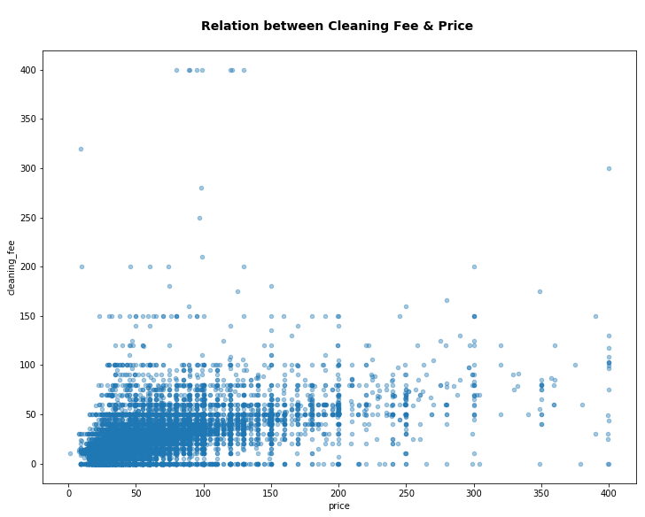

```python
df[df['price']<=400].plot.scatter(x="price", y="cleaning_fee", figsize=(12,9), alpha=0.4)
plt.title('\nRelation between Cleaning Fee & Price \n', fontsize=14, fontweight='bold')
```

# 5. Modelling the data

## 5.1 Preparing the features and the target variable

```python
df.info()
```

```
<class 'pandas.core.frame.DataFrame'>
Int64Index: 20592 entries, 2015 to 29867352
Data columns (total 28 columns):
accommodates                    20592 non-null int64
bathrooms                       20592 non-null float64
bedrooms                        20592 non-null int64
beds                            20592 non-null int64
price                           20592 non-null float64
security_deposit                20592 non-null float64
cleaning_fee                    20592 non-null float64
name                            20592 non-null object
summary                         20592 non-null object
description                     20592 non-null object
neighbourhood_cleansed          20592 non-null object
neighbourhood_group_cleansed    20592 non-null object
zipcode                         20592 non-null int64
latitude                        20592 non-null float64
longitude                       20592 non-null float64
property_type                   20592 non-null object
room_type                       20592 non-null object
bed_type                        20592 non-null object
guests_included                 20592 non-null int64
extra_people                    20592 non-null int64
minimum_nights                  20592 non-null int64
is_business_travel_ready        20592 non-null object
cancellation_policy             20592 non-null object
distance                        20592 non-null float64
Laptop friendly                 20592 non-null int64
Family friendly                 20592 non-null int64
Host greets you                 20592 non-null int64
First aid kit                   20592 non-null int64
dtypes: float64(7), int64(11), object(10)
memory usage: 4.6+ MB
```

Before we train the final model we should get rid of some last features. E.g the information of "latitude" and "longitude" is covered by "zipcode".

Other columns provide qualitative information I decided to exclude:

```python
cols_to_drop = ['latitude', 'longitude', 'name', 'summary', 'description',
                'neighbourhood_cleansed', 'neighbourhood_group_cleansed']


df = df.drop(columns=cols_to_drop)
```

Let's get the dummies of the kept qulitative information.

First, let's convert all string columns into categorical ones:

```python
for col in ['cancellation_policy', 'property_type', 'bed_type', 'room_type']:
    df[col] = df[col].astype('category')
```

```python
# Target vaiable
target = df[["price"]]

# Features
features = df.drop(["price"], axis=1)
```

Let's transform all categorical data to numerical

```python
#Getting dummies

df_num = features.select_dtypes(include=['float64','int64']).copy()

df_cat = features.select_dtypes(include=['category']).copy()


df_cat = pd.get_dummies(df_cat)

final_feat = pd.concat([df_num, df_cat], axis=1)

final_feat
```

|  | accommodates | bathrooms | bedrooms | beds | security_deposit | cleaning_fee | zipcode | guests_included | extra_people | minimum_nights | distance | Laptop friendly | Family friendly | Host greets you | First aid kit | property_type_Aparthotel | property_type_Apartment | property_type_Barn | property_type_Bed and breakfast | property_type_Boat | property_type_Boutique hotel | property_type_Bungalow | property_type_Cabin | property_type_Camper/RV | property_type_Casa particular (Cuba) | property_type_Castle | property_type_Cave | property_type_Chalet | property_type_Condominium | … |
| --- | --- | --- | --- | --- | --- | --- | --- | --- | --- | --- | --- | --- | --- | --- | --- | --- | --- | --- | --- | --- | --- | --- | --- | --- | --- | --- | --- | --- | --- | --- |
| 2015 | 3 | 1.0 | 1 | 2 | 200.000000 | 30.000000 | 10119 | 1 | 28 | 4 | 3.533182 | 1 | 1 | 0 | 0 | 0 | 0 | 0 | 0 | 0 | 0 | 0 | 0 | 0 | 0 | 0 | 0 | 0 | 0 | … |
| 3176 | 4 | 1.0 | 1 | 2 | 200.000000 | 50.000000 | 10405 | 2 | 20 | 62 | 3.695677 | 1 | 1 | 0 | 1 | 0 | 1 | 0 | 0 | 0 | 0 | 0 | 0 | 0 | 0 | 0 | 0 | 0 | 0 | … |
| 3309 | 2 | 1.0 | 1 | 1 | 250.000000 | 30.000000 | 10777 | 1 | 18 | 5 | 3.755285 | 1 | 0 | 1 | 0 | 0 | 1 | 0 | 0 | 0 | 0 | 0 | 0 | 0 | 0 | 0 | 0 | 0 | 0 | … |
| 7071 | 2 | 1.0 | 1 | 2 | 0.000000 | 0.000000 | 10437 | 1 | 24 | 2 | 4.550423 | 1 | 1 | 0 | 0 | 0 | 1 | 0 | 0 | 0 | 0 | 0 | 0 | 0 | 0 | 0 | 0 | 0 | 0 | … |
| 9991 | 7 | 2.5 | 4 | 7 | 400.000000 | 80.000000 | 10405 | 5 | 10 | 6 | 3.458693 | 0 | 1 | 0 | 0 | 0 | 1 | 0 | 0 | 0 | 0 | 0 | 0 | 0 | 0 | 0 | 0 | 0 | 0 | … |
| 14325 | 2 | 1.0 | 0 | 1 | 500.000000 | 0.000000 | 10437 | 1 | 0 | 90 | 5.012297 | 0 | 0 | 1 | 0 | 0 | 1 | 0 | 0 | 0 | 0 | 0 | 0 | 0 | 0 | 0 | 0 | 0 | 0 | … |
| 16644 | 5 | 1.0 | 1 | 3 | 500.000000 | 50.000000 | 10997 | 2 | 20 | 60 | 2.105810 | 1 | 1 | 0 | 1 | 0 | 1 | 0 | 0 | 0 | 0 | 0 | 0 | 0 | 0 | 0 | 0 | 0 | 0 | … |
| 17409 | 2 | 1.0 | 1 | 1 | 0.000000 | 18.000000 | 10405 | 1 | 26 | 3 | 2.982036 | 1 | 0 | 1 | 0 | 0 | 0 | 0 | 0 | 0 | 0 | 0 | 0 | 0 | 0 | 0 | 0 | 0 | 1 | … |
| 20858 | 4 | 1.0 | 2 | 2 | 500.000000 | 49.000000 | 10435 | 2 | 24 | 3 | 3.807207 | 0 | 1 | 0 | 0 | 0 | 0 | 0 | 0 | 0 | 0 | 0 | 0 | 0 | 0 | 0 | 0 | 0 | 0 | … |
| 21869 | 4 | 1.0 | 1 | 2 | 500.000000 | 40.000000 | 10997 | 2 | 18 | 60 | 2.061292 | 1 | 1 | 0 | 0 | 0 | 1 | 0 | 0 | 0 | 0 | 0 | 0 | 0 | 0 | 0 | 0 | 0 | 0 | … |
| 22415 | 4 | 1.0 | 2 | 2 | 300.000000 | 50.000000 | 10999 | 2 | 25 | 3 | 1.868255 | 1 | 1 | 1 | 0 | 0 | 1 | 0 | 0 | 0 | 0 | 0 | 0 | 0 | 0 | 0 | 0 | 0 | 0 | … |
| 22677 | 5 | 1.0 | 1 | 4 | 150.000000 | 40.000000 | 10119 | 4 | 35 | 3 | 3.511787 | 1 | 1 | 0 | 1 | 0 | 1 | 0 | 0 | 0 | 0 | 0 | 0 | 0 | 0 | 0 | 0 | 0 | 0 | … |
| 23834 | 4 | 1.0 | 1 | 4 | 500.000000 | 50.000000 | 10965 | 1 | 0 | 60 | 2.200622 | 1 | 1 | 1 | 0 | 0 | 0 | 0 | 0 | 0 | 0 | 0 | 0 | 0 | 0 | 0 | 0 | 0 | 1 | … |
| 26543 | 8 | 2.0 | 2 | 8 | 250.000000 | 50.000000 | 10437 | 4 | 40 | 3 | 4.735999 | 1 | 1 | 1 | 0 | 0 | 1 | 0 | 0 | 0 | 0 | 0 | 0 | 0 | 0 | 0 | 0 | 0 | 0 | … |
| 28268 | 6 | 1.0 | 2 | 4 | 200.000000 | 50.000000 | 10247 | 4 | 20 | 5 | 4.605567 | 0 | 1 | 0 | 0 | 0 | 1 | 0 | 0 | 0 | 0 | 0 | 0 | 0 | 0 | 0 | 0 | 0 | 0 | … |
| 30295 | 8 | 1.0 | 2 | 4 | 165.441830 | 40.000000 | 10437 | 4 | 20 | 4 | 4.957658 | 1 | 1 | 0 | 0 | 0 | 1 | 0 | 0 | 0 | 0 | 0 | 0 | 0 | 0 | 0 | 0 | 0 | 0 | … |
| 31440 | 1 | 1.0 | 1 | 1 | 100.000000 | 15.000000 | 10437 | 1 | 15 | 1 | 4.650043 | 0 | 0 | 0 | 0 | 0 | 1 | 0 | 0 | 0 | 0 | 0 | 0 | 0 | 0 | 0 | 0 | 0 | 0 | … |
| 33043 | 4 | 1.0 | 1 | 2 | 0.000000 | 20.000000 | 10557 | 2 | 8 | 3 | 3.801148 | 1 | 1 | 0 | 0 | 0 | 1 | 0 | 0 | 0 | 0 | 0 | 0 | 0 | 0 | 0 | 0 | 0 | 0 | … |
| 35642 | 2 | 1.0 | 1 | 1 | 1000.000000 | 50.000000 | 10437 | 1 | 10 | 60 | 5.266471 | 0 | 0 | 0 | 0 | 0 | 1 | 0 | 0 | 0 | 0 | 0 | 0 | 0 | 0 | 0 | 0 | 0 | 0 | … |
| 36480 | 1 | 0.0 | 1 | 1 | 500.000000 | 5.000000 | 10587 | 1 | 20 | 1 | 7.159022 | 1 | 0 | 1 | 0 | 0 | 1 | 0 | 0 | 0 | 0 | 0 | 0 | 0 | 0 | 0 | 0 | 0 | 0 | … |
| 37004 | 1 | 1.0 | 1 | 1 | 0.000000 | 0.000000 | 10783 | 1 | 15 | 5 | 2.861256 | 1 | 1 | 1 | 0 | 0 | 1 | 0 | 0 | 0 | 0 | 0 | 0 | 0 | 0 | 0 | 0 | 0 | 0 | … |
| 37052 | 2 | 1.0 | 1 | 2 | 100.000000 | 30.000000 | 10435 | 1 | 12 | 2 | 3.941158 | 1 | 1 | 0 | 0 | 0 | 1 | 0 | 0 | 0 | 0 | 0 | 0 | 0 | 0 | 0 | 0 | 0 | 0 | … |
| 38074 | 2 | 1.0 | 1 | 1 | 500.000000 | 27.368001 | 10405 | 2 | 0 | 84 | 4.048425 | 1 | 0 | 1 | 0 | 0 | 1 | 0 | 0 | 0 | 0 | 0 | 0 | 0 | 0 | 0 | 0 | 0 | 0 | … |
| 38296 | 2 | 1.0 | 1 | 2 | 500.000000 | 35.000000 | 12049 | 2 | 0 | 10 | 2.296091 | 0 | 1 | 0 | 0 | 0 | 1 | 0 | 0 | 0 | 0 | 0 | 0 | 0 | 0 | 0 | 0 | 0 | 0 | … |
| 41217 | 2 | 1.0 | 1 | 1 | 144.586961 | 20.042542 | 10435 | 1 | 13 | 2 | 3.779877 | 0 | 0 | 1 | 0 | 0 | 1 | 0 | 0 | 0 | 0 | 0 | 0 | 0 | 0 | 0 | 0 | 0 | 0 | … |
| 41306 | 2 | 1.0 | 1 | 1 | 141.205654 | 19.448586 | 10405 | 1 | 0 | 1 | 3.325620 | 0 | 0 | 0 | 0 | 0 | 1 | 0 | 0 | 0 | 0 | 0 | 0 | 0 | 0 | 0 | 0 | 0 | 0 | … |
| 42809 | 4 | 1.0 | 2 | 3 | 231.319911 | 45.000000 | 10245 | 2 | 10 | 4 | 3.605957 | 1 | 1 | 1 | 0 | 0 | 1 | 0 | 0 | 0 | 0 | 0 | 0 | 0 | 0 | 0 | 0 | 0 | 0 | … |
| 43123 | 4 | 1.0 | 1 | 1 | 300.000000 | 50.000000 | 10435 | 2 | 20 | 5 | 4.091367 | 1 | 1 | 0 | 0 | 0 | 1 | 0 | 0 | 0 | 0 | 0 | 0 | 0 | 0 | 0 | 0 | 0 | 0 | … |
| 44083 | 2 | 1.0 | 1 | 1 | 1000.000000 | 20.000000 | 12435 | 2 | 10 | 3 | 2.838961 | 1 | 1 | 1 | 1 | 0 | 1 | 0 | 0 | 0 | 0 | 0 | 0 | 0 | 0 | 0 | 0 | 0 | 0 | … |
| 44423 | 2 | 1.0 | 1 | 1 | 300.000000 | 25.000000 | 10245 | 1 | 10 | 2 | 3.597300 | 0 | 0 | 0 | 0 | 0 | 1 | 0 | 0 | 0 | 0 | 0 | 0 | 0 | 0 | 0 | 0 | 0 | 0 | … |
| ... | ... | ... | ... | ... | ... | ... | ... | ... | ... | ... | ... | ... | ... | ... | ... | ... | ... | ... | ... | ... | ... | ... | ... | ... | ... | ... | ... | ... | ... | … |
| 29825372 | 4 | 1.0 | 1 | 2 | 0.000000 | 5.000000 | 12103 | 2 | 10 | 3 | 5.039311 | 1 | 0 | 1 | 0 | 0 | 1 | 0 | 0 | 0 | 0 | 0 | 0 | 0 | 0 | 0 | 0 | 0 | 0 | … |
| 29826161 | 4 | 1.0 | 2 | 2 | 184.353505 | 32.620950 | 14059 | 1 | 0 | 10 | 7.517631 | 1 | 0 | 0 | 0 | 0 | 1 | 0 | 0 | 0 | 0 | 0 | 0 | 0 | 0 | 0 | 0 | 0 | 0 | … |
| 29827481 | 2 | 1.0 | 1 | 1 | 129.934630 | 17.468732 | 10245 | 1 | 0 | 1 | 4.368093 | 0 | 0 | 0 | 0 | 0 | 1 | 0 | 0 | 0 | 0 | 0 | 0 | 0 | 0 | 0 | 0 | 0 | 0 | … |
| 29828388 | 2 | 1.0 | 1 | 1 | 120.917811 | 15.884849 | 12163 | 1 | 0 | 1 | 7.186113 | 0 | 0 | 0 | 0 | 0 | 1 | 0 | 0 | 0 | 0 | 0 | 0 | 0 | 0 | 0 | 0 | 0 | 0 | … |
| 29829280 | 2 | 1.0 | 1 | 1 | 146.841166 | 20.438512 | 10115 | 1 | 0 | 2 | 3.809701 | 1 | 0 | 0 | 0 | 0 | 1 | 0 | 0 | 0 | 0 | 0 | 0 | 0 | 0 | 0 | 0 | 0 | 0 | … |
| 29830140 | 2 | 1.0 | 1 | 1 | 0.000000 | 30.000000 | 10717 | 1 | 36 | 2 | 5.124360 | 0 | 0 | 0 | 0 | 0 | 1 | 0 | 0 | 0 | 0 | 0 | 0 | 0 | 0 | 0 | 0 | 0 | 0 | … |
| 29830204 | 2 | 1.0 | 0 | 1 | 150.000000 | 30.000000 | 10585 | 2 | 0 | 7 | 5.926380 | 1 | 0 | 0 | 1 | 0 | 1 | 0 | 0 | 0 | 0 | 0 | 0 | 0 | 0 | 0 | 0 | 0 | 0 | … |
| 29830381 | 2 | 0.5 | 1 | 1 | 200.000000 | 25.000000 | 10997 | 1 | 10 | 7 | 1.140742 | 0 | 1 | 0 | 0 | 0 | 1 | 0 | 0 | 0 | 0 | 0 | 0 | 0 | 0 | 0 | 0 | 0 | 0 | … |
| 29838765 | 2 | 1.0 | 1 | 1 | 129.934630 | 17.468732 | 12247 | 1 | 0 | 1 | 7.727114 | 0 | 0 | 0 | 0 | 0 | 1 | 0 | 0 | 0 | 0 | 0 | 0 | 0 | 0 | 0 | 0 | 0 | 0 | … |
| 29841234 | 5 | 1.0 | 1 | 1 | 0.000000 | 49.000000 | 10777 | 2 | 0 | 1 | 4.133730 | 1 | 0 | 0 | 1 | 0 | 1 | 0 | 0 | 0 | 0 | 0 | 0 | 0 | 0 | 0 | 0 | 0 | 0 | … |
| 29842909 | 2 | 1.0 | 0 | 1 | 190.041181 | 29.287834 | 12047 | 1 | 0 | 1 | 1.988263 | 1 | 0 | 0 | 0 | 0 | 0 | 0 | 0 | 0 | 0 | 0 | 0 | 0 | 0 | 0 | 0 | 0 | 0 | … |
| 29844866 | 2 | 1.0 | 1 | 1 | 135.570142 | 18.458659 | 10827 | 1 | 0 | 1 | 3.763600 | 1 | 0 | 0 | 0 | 0 | 1 | 0 | 0 | 0 | 0 | 0 | 0 | 0 | 0 | 0 | 0 | 0 | 0 | … |
| 29846605 | 4 | 3.0 | 2 | 2 | 0.000000 | 60.000000 | 12045 | 1 | 15 | 1 | 3.025901 | 1 | 0 | 0 | 0 | 0 | 1 | 0 | 0 | 0 | 0 | 0 | 0 | 0 | 0 | 0 | 0 | 0 | 0 | … |
| 29848269 | 2 | 1.0 | 1 | 1 | 203.196286 | 30.337781 | 10178 | 1 | 0 | 5 | 2.343168 | 0 | 0 | 0 | 0 | 0 | 1 | 0 | 0 | 0 | 0 | 0 | 0 | 0 | 0 | 0 | 0 | 0 | 0 | … |
| 29848903 | 4 | 1.0 | 2 | 4 | 134.017209 | 24.154607 | 10407 | 1 | 0 | 21 | 4.255126 | 0 | 0 | 0 | 0 | 0 | 1 | 0 | 0 | 0 | 0 | 0 | 0 | 0 | 0 | 0 | 0 | 0 | 0 | … |
| 29848907 | 2 | 1.0 | 1 | 1 | 125.426220 | 16.676790 | 13189 | 1 | 0 | 60 | 7.522113 | 1 | 0 | 0 | 0 | 0 | 1 | 0 | 0 | 0 | 0 | 0 | 0 | 0 | 0 | 0 | 0 | 0 | 0 | … |
| 29849186 | 1 | 1.0 | 1 | 1 | 131.658845 | 14.438557 | 13189 | 1 | 0 | 60 | 7.523551 | 1 | 0 | 0 | 0 | 0 | 1 | 0 | 0 | 0 | 0 | 0 | 0 | 0 | 0 | 0 | 0 | 0 | 0 | … |
| 29849565 | 4 | 1.0 | 2 | 2 | 263.250673 | 46.479926 | 10435 | 1 | 0 | 10 | 3.799491 | 1 | 0 | 0 | 0 | 0 | 1 | 0 | 0 | 0 | 0 | 0 | 0 | 0 | 0 | 0 | 0 | 0 | 0 | … |
| 29849958 | 1 | 1.0 | 1 | 1 | 133.913050 | 14.834528 | 13189 | 1 | 0 | 60 | 7.493571 | 1 | 0 | 0 | 0 | 0 | 1 | 0 | 0 | 0 | 0 | 0 | 0 | 0 | 0 | 0 | 0 | 0 | 0 | … |
| 29850404 | 2 | 1.0 | 0 | 1 | 144.957085 | 21.368419 | 10967 | 1 | 0 | 1 | 1.307927 | 1 | 0 | 0 | 1 | 0 | 1 | 0 | 0 | 0 | 0 | 0 | 0 | 0 | 0 | 0 | 0 | 0 | 0 | … |
| 29850727 | 2 | 1.0 | 1 | 1 | 129.934630 | 17.468732 | 10245 | 1 | 0 | 1 | 4.110236 | 0 | 0 | 0 | 0 | 0 | 1 | 0 | 0 | 0 | 0 | 0 | 0 | 0 | 0 | 0 | 0 | 0 | 0 | … |
| 29851223 | 2 | 1.0 | 1 | 1 | 0.000000 | 0.000000 | 12059 | 1 | 10 | 2 | 4.086769 | 1 | 0 | 0 | 0 | 0 | 1 | 0 | 0 | 0 | 0 | 0 | 0 | 0 | 0 | 0 | 0 | 0 | 0 | … |
| 29853463 | 1 | 1.0 | 1 | 1 | 140.675665 | 16.022440 | 12055 | 1 | 0 | 2 | 4.519921 | 1 | 0 | 0 | 0 | 0 | 1 | 0 | 0 | 0 | 0 | 0 | 0 | 0 | 0 | 0 | 0 | 0 | 0 | … |
| 29856029 | 4 | 1.0 | 2 | 2 | 100.000000 | 20.000000 | 10247 | 1 | 0 | 2 | 3.847479 | 1 | 0 | 0 | 1 | 0 | 1 | 0 | 0 | 0 | 0 | 0 | 0 | 0 | 0 | 0 | 0 | 0 | 0 | … |
| 29856359 | 4 | 1.0 | 1 | 2 | 0.000000 | 10.000000 | 10243 | 1 | 10 | 1 | 2.874725 | 1 | 0 | 0 | 0 | 0 | 1 | 0 | 0 | 0 | 0 | 0 | 0 | 0 | 0 | 0 | 0 | 0 | 0 | … |
| 29856708 | 2 | 1.0 | 1 | 1 | 163.747702 | 23.408293 | 10119 | 1 | 0 | 2 | 3.464543 | 1 | 0 | 0 | 0 | 0 | 1 | 0 | 0 | 0 | 0 | 0 | 0 | 0 | 0 | 0 | 0 | 0 | 0 | … |
| 29857108 | 6 | 1.0 | 1 | 4 | 0.000000 | 0.000000 | 10777 | 1 | 10 | 1 | 4.288544 | 1 | 0 | 0 | 0 | 0 | 1 | 0 | 0 | 0 | 0 | 0 | 0 | 0 | 0 | 0 | 0 | 0 | 0 | … |
| 29864272 | 2 | 1.0 | 0 | 1 | 173.134645 | 26.318054 | 10119 | 1 | 0 | 3 | 3.270333 | 0 | 0 | 0 | 0 | 0 | 0 | 0 | 0 | 0 | 0 | 0 | 0 | 0 | 0 | 0 | 0 | 0 | 0 | … |
| 29866805 | 2 | 1.0 | 1 | 1 | 207.704696 | 31.129723 | 10117 | 1 | 0 | 1 | 2.643811 | 1 | 1 | 0 | 0 | 0 | 0 | 0 | 0 | 0 | 1 | 0 | 0 | 0 | 0 | 0 | 0 | 0 | 0 | … |
| 29867352 | 2 | 1.0 | 1 | 1 | 146.841166 | 20.438512 | 12049 | 1 | 0 | 5 | 3.506518 | 1 | 0 | 0 | 0 | 0 | 1 | 0 | 0 | 0 | 0 | 0 | 0 | 0 | 0 | 0 | 0 | 0 | 0 | … |

20592 rows × 60 columns

## 5.2 Splitting & scaling the data

```python
# import train_test_split function
from sklearn.model_selection import train_test_split
# import metrics
from sklearn.metrics import mean_squared_error, r2_score, mean_absolute_error

# split our data
X_train, X_test, y_train, y_test = train_test_split(final_feat, target, test_size=0.2)
```

The different features have different scales. This can be problematic when building a model/finding proper coefficients.

In order to tackle this problem, we standardize or normalize the features.

```python
# scale data
from sklearn.preprocessing import StandardScaler
sc = StandardScaler()
X_train = sc.fit_transform(X_train)
X_test  = sc.transform(X_test)
```

## 5.3 Training XGBoostRegressor

```python
import xgboost as xgb

booster = xgb.XGBRegressor()
```

```python
from sklearn.model_selection import RandomizedSearchCV

# create Grid
param_grid = {'n_estimators': [100, 200, 500],
              'learning_rate': [0.01, 0.05, 0.1],
              'max_depth': [4, 5, 6, 7, 8],
              'colsample_bytree': [0.6, 0.7, 1],
              'gamma': [0.0, 0.1, 0.2],
              'objective' : ['reg:squarederror']}

# instantiate the tuned random forest
booster_grid_search = RandomizedSearchCV(booster, param_grid, cv=3, n_jobs=-1)

# train the tuned random forest
booster_grid_search.fit(X_train, y_train)

# print best estimator parameters found during the grid search
print(booster_grid_search.best_params_)
```

```
{'objective': 'reg:squarederror', 'n_estimators': 100, 'max_depth': 7, 'learning_rate': 0.05, 'gamma': 0.1, 'colsample_bytree': 0.7}
```

```python
# instantiate xgboost with best parameters
booster = xgb.XGBRegressor(colsample_bytree=0.7, gamma=0.0, learning_rate=0.1,
                           max_depth=7, n_estimators=500, random_state=4)

# train
booster.fit(X_train, y_train)

# predict
y_pred_train = booster.predict(X_train)
y_pred_test = booster.predict(X_test)
```

```
[22:21:32] WARNING: src/objective/regression_obj.cu:152: reg:linear is now deprecated in favor of reg:squarederror.
```

```python
RMSE = np.sqrt(mean_squared_error(y_test, y_pred_test))
print(f"RMSE: {round(RMSE, 4)}")
```

```
RMSE: 22.1309
```

```python
r2 = r2_score(y_test, y_pred_test)
r2
print(f"r2: {round(r2, 4)}")
```

```
r2: 0.7275
```

## 5.4 Cross Validation

To build a more robust model, we'll conduct a k-fold cross validation:

```python
xg_train = xgb.DMatrix(data=X_train, label=y_train)
```

```python
params = {'n_estimators':500,'colsample_bytree':0.6, 'gamma':0.0, 'learning_rate':0.1, 'max_depth':7}

cv_results = xgb.cv(dtrain=xg_train, params=params, nfold=3,
                    num_boost_round=200, early_stopping_rounds=10,
                    metrics="rmse", as_pandas=True)
```

```python
cv_results.head()
```

|  | train-rmse-mean | train-rmse-std | test-rmse-mean | test-rmse-std |
| --- | --- | --- | --- | --- |
| 0 | 64.554024 | 0.398839 | 64.641230 | 0.906995 |
| 1 | 59.223326 | 0.306957 | 59.467508 | 0.969106 |
| 2 | 54.453028 | 0.249506 | 54.895704 | 0.954405 |
| 3 | 50.306836 | 0.211277 | 50.921091 | 0.993460 |
| 4 | 46.541627 | 0.126361 | 47.354388 | 1.037453 |

```python
cv_results.tail()
```

|  | train-rmse-mean | train-rmse-std | test-rmse-mean | test-rmse-std |
| --- | --- | --- | --- | --- |
| 195 | 11.371297 | 0.138811 | 22.839734 | 0.188531 |
| 196 | 11.339349 | 0.140197 | 22.841099 | 0.189591 |
| 197 | 11.327148 | 0.136076 | 22.840410 | 0.191547 |
| 198 | 11.299249 | 0.125504 | 22.837124 | 0.199282 |
| 199 | 11.288908 | 0.117651 | 22.836361 | 0.199213 |

The final model seems to overfit as the Mean-Test-RMSE is nearly twice as big as the Mean-Train-RMSE. Let's have a look:

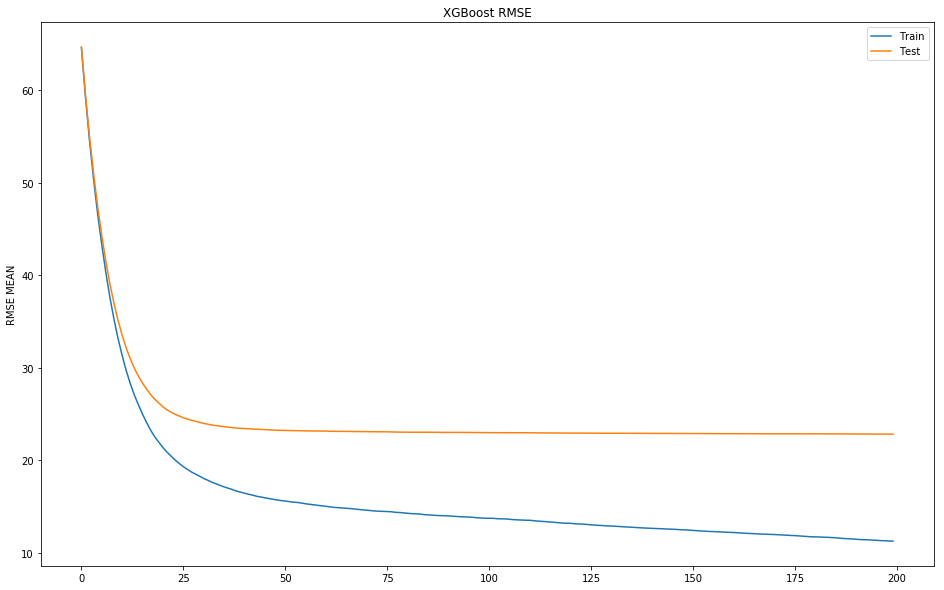

```python
epochs = len(cv_results['train-rmse-mean'])
x_axis = range(0, epochs)


fig, ax = plt.subplots(figsize=[16,10])
ax.plot(x_axis, cv_results['train-rmse-mean'], label='Train')
ax.plot(x_axis, cv_results['test-rmse-mean'], label='Test')
ax.legend()
plt.ylabel('RMSE MEAN')
plt.title('XGBoost RMSE')
plt.show()
```

Let's also have a look at the different feature importances:

[figure not shown]

```python
# plot the important features
feat_importances = pd.Series(booster.feature_importances_, index=final_feat.columns)
feat_importances.nlargest(15).sort_values().plot(kind='barh', color='darkgrey', figsize=(10,5))
plt.xlabel('Relative Feature Importance with XGBoost');
```

# 6. Interpretation

## 6.1 Status Quo

We can see that our average training error (train-RMSE) differs from the average test error (test-RMSE). This means that our current model is overfitting.

It turns out that the price is dependent not only on geography, size, and features. It stands to reason that

the quality of presentation (e.g. pictures), availability, the number and content of reviews, communication (e.g. acceptance rate, host response time) or status ((whether or not the host is a super host)) might have a substantial influence too. But the purpose of this analysis was to recommend a price to a "rookie" without any reviews or status. With this in mind, we might say that we can't recommend an exact price, but rather a range..

## 6.2 Further ideas

In order to optimize the performance of the current model it could be useful to try the following ideas:

- Including more features such as the ones mentioned above (e.g availability/number and content of reviews)
- Implementing an "Outlier Finder. The range of prices for different apartments had a range from 0 to 9000 dollar. For our model we excluded all objects which followed a non normal distribution for the price column. That improves the average training error by around 42 dollar. But excluding data always means excluding knowledge. So it could be useful to implement a classifier that tags the outliers and separates them from the rest of the data.
- The fact that the model is overfitting leads to the idea of further hyperparamter tuning. Especially tuning regularization (e.g Gamma) could lead to a more robust model